[figure not shown]

# Exponential Function

In this notebook, we review some properties of the complex exponential function. This function plays an important role for defining and understanding the Fourier transform, see Section 2.3.2 of [[Müller, FMP, Springer 2015]](http://www.music-processing.de).

## Power Series

The complex exponential function $\exp:\mathbb{C}\to \mathbb{C}$ is defined by the power series

$$\mathrm{exp}(c) = e^c := \sum_{n=0}^{\infty} \frac{c^n}{n!} = 1 + c + \frac{c^2}{1 \cdot 2} + \frac{c^3}{1 \cdot 2 \cdot 3} + \dots$$

for $c\in\mathbb{C}$. Note that this definition is an extension of real exponential function, where the real variable is replaced by a complex one. Based on the definition of the complex exponential function, one can also extend the definition of trigonometric functions (e.g. $\sin$ and $\cos$) to complex arguments.

The following implementation yields an approximation of the power series by considering only the first $N$ terms specified by the parameter $N\in\mathbb{N}$. For the case $c=1$, this yields an approximation for the number $e$.

```python
import numpy as np

def exp_power_series(c, N):
    """Compute power series for exponential function

    Notebook: C2_ExponentialFunction.ipynb

    Args:
        c: Complex number
        N: Number of summands used for approximation

    Returns:
        exp_c: Approximation of exp(c)
    """
    exp_c = 1
    c_power = 1
    nfac = 1
    for n in range(1, N):
        nfac *= n
        c_power *= c
        exp_c += c_power / nfac
    return exp_c

c=1
print('Approximation (N =  1):', exp_power_series(c, 1))
print('Approximation (N =  2):', exp_power_series(c, 2))
print('Approximation (N =  4):', exp_power_series(c, 4))
print('Approximation (N =  8):', exp_power_series(c, 8))
print('Approximation (N = 12):', exp_power_series(c, 12))
print('Numpy:                 ', np.exp(c))
```

```
Approximation (N =  1): 1
Approximation (N =  2): 2.0
Approximation (N =  4): 2.6666666666666665
Approximation (N =  8): 2.7182539682539684
Approximation (N = 12): 2.718281826198493
Numpy:                  2.718281828459045
```

## Euler's Formula

for $c\in\mathbb{C}$. In particular, the case $c = i\gamma$ with some real-valued $\gamma\in\mathbb{R}$ becomes relevant for us. In this case, Euler's formula reduces to

$$\mathrm{exp}(i\gamma) = \cos(\gamma) + i\sin(\gamma),$$

where the only the real sine and cosine function appears. Actually, starting with the real sine and cosine functions, one often defines $\mathrm{exp}(i\gamma)$ by means of the Euler identity (rather than using the power series).

## Basic Properties

The exponential function has a number of interesting properties:

\begin{eqnarray} \exp(i\gamma) & = & \exp(i(\gamma+2\pi)) \\ |\exp(i\gamma)| & = & 1 \\ \overline{\exp(i\gamma)} & = & \exp(-i\gamma) \\ \exp(i(\gamma_1+\gamma_2)) & = & \exp(i\gamma_1) \exp(i\gamma_2) \\ \frac{d\exp(i\gamma)}{d\gamma} & = & i\exp(i\gamma) \end{eqnarray}

In particular, note that the complex values $\mathrm{exp}(i\gamma)$ lie on the unit circle of the complex plane for all $\gamma\in\mathbb{R}$. Furthermore, due to periodicity, it suffices to consider $\gamma\in[0,2\pi)$. In fact, $\gamma$ encodes the angle (in radiants) of the complex number $c = \mathrm{exp}(i\gamma)$, while $|c|=1$. The following visualization shows how the values $\mathrm{exp}(i\gamma)$ change when increasing the angle $\gamma$ from $0$ to $2\pi$:

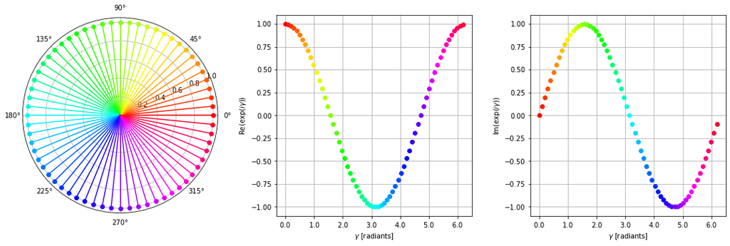

```python
from matplotlib import pyplot as plt
from matplotlib import ticker
%matplotlib inline

cmap = plt.cm.get_cmap('hsv') # hsv is nice because it is a circular color map

N = 64

fig = plt.figure(figsize=(5 * 3, 5))
ax1 = fig.add_subplot(1, 3, 1, projection='polar')
ax2 = fig.add_subplot(1, 3, 2)
ax3 = fig.add_subplot(1, 3, 3)

for i in range(N):
    gamma = 2 * np.pi * i / N
    c = np.exp(1j * gamma)
    color = cmap(i / N)
    ax1.plot([0, np.angle(c)], [0, np.abs(c)], color=color)
    ax1.plot(np.angle(c), np.abs(c), 'o', color=color)
    ax2.plot(gamma, np.real(c), 'o', color=color)
    ax3.plot(gamma, np.imag(c), 'o', color=color)

ax2.grid()
ax2.set_xlabel('$\gamma$ [radiants]')
ax2.set_ylabel('$\mathrm{Re}(\exp(i \gamma))$')
ax2.xaxis.set_major_formatter(ticker.FormatStrFormatter('$%s$'))

ax3.grid()
ax3.set_xlabel('$\gamma$ [radiants]')
ax3.set_ylabel('$\mathrm{Im}(\exp(i \gamma))$')
ax3.xaxis.set_major_formatter(ticker.FormatStrFormatter('$%s$'))
plt.tight_layout()
```

## Roots of Unity

Let $N \in \mathbb{N}_{>0}$ be a positive integer. A complex number $\rho \in \mathbb{C}$ is called an $N^\mathrm{th}$ **root of unity** if $\rho^N = 1$. It is not hard to see that there are exactly $N$ distinct $N^\mathrm{th}$ roots of unity. Additionally, if $\rho^n \neq 1$ for all $n\in [1:N-1]$, it is called a **primitive** $N^\mathrm{th}$ root of unity.

With the properties mentioned above, it is easy to see that $\rho_N:=\exp(2 \pi i / N)$ is such a **primitive** $N^\mathrm{th}$ root of unity. All $N^\mathrm{th}$ roots of unity can be generated by considering powers of $\rho_N$:

$$1=\rho_N^0, \quad \rho_N^1, \quad \rho_N^2, \quad ...,\quad \rho_N^{N-1}$$

The following plot shows all roots of unity for different integers $N \in \mathbb{N}_{>0}$. The primitive roots are indicated in red.

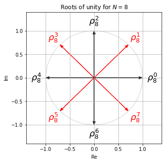

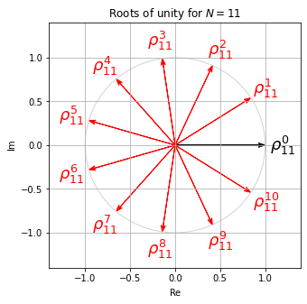

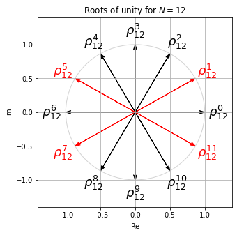

```python
from math import gcd
import sys
sys.path.append('..')
import LibFMP.C2

def plot_root_unity(N, figsize=(5, 5)):
    root_unity = np.exp(2j * np.pi / N)
    root_unity_power = 1

    fig, ax = plt.subplots(figsize=figsize)
    plt.grid()
    plt.xlim([-1.4, 1.4])
    plt.ylim([-1.4, 1.4])
    plt.xlabel('$\mathrm{Re}$')
    plt.ylabel('$\mathrm{Im}$')
    plt.title('Roots of unity for $N=%d$'%N)

    for n in range(0, N):
        colorPlot = 'r' if gcd(n, N) == 1 else 'k'
        LibFMP.C2.plot_vector(root_unity_power, color=colorPlot)
        plt.text(np.real(1.2*root_unity_power), np.imag(1.2*root_unity_power),
                 r'$\rho_{%s}^{%s}$' % (N, n), size='18',
                 color=colorPlot, ha='center', va='center')
        root_unity_power *= root_unity

    circle_unit = plt.Circle((0, 0), 1, color='lightgray', fill=0)
    ax.add_artist(circle_unit)

plot_root_unity(N=8)
plot_root_unity(N=11)
plot_root_unity(N=12)
```

**Acknowledgment:** This notebook was created by [Meinard Müller](https://www.audiolabs-erlangen.de/fau/professor/mueller) and [Frank Zalkow](https://www.audiolabs-erlangen.de/fau/assistant/zalkow).